# Changing Minds on Gay Marriage: Revisited

In this exercise, we revisit the gay marriage study we analyzed previously. It is important to work on that exercise before answering the following questions.

In May 2015, three scholars reported several irregularities in the dataset used to produce the results in the study. This exercise is based on the unpublished report ‘Irregularities in LaCour (2014)’ by David Broockman, Joshua Kalla, and Peter Aronow.

They found that the gay marriage experimental data were statistically indistinguishable from data in the Cooperative Campaign Analysis Project (CCAP), which interviewed voters throughout the 2012 United States presidential campaign. The scholars suggested that the CCAP survey data – and not the original data alleged to have been collected in the experiment – were used to produce the results reported in the gay marriage study. The release of a report on these irregularities ultimately led to the retraction of the original article. In this exercise, we will use several measurement strategies to reproduce the irregularities observed in the gay marriage dataset.

To do so, we will use four CSV data files. The first three, `gayreshaped.csv`, `gayreshaped_study1.csv` and `gayreshaped_study2.csv`, are reshaped versions of the original dataset in which every observation corresponds to a unique respondent from both studies 1 and 2, study 1, and study 2, respectively. The variables in these files are:

| Name | Description |
| --- | --- |
| `study` | Which study the data set is from (1 = Study1, 2 = Study2) |
| `treatment` | Five possible treatment assignment options |
| `therm1` | Survey thermometer rating of feeling towards gay couples in wave 1 (0–100) |
| `therm2` | Survey thermometer rating of feeling towards gay couples in wave 2 (0–100) |
| `therm3` | Survey thermometer rating of feeling towards gay couples in wave 3 (0–100) |
| `therm4` | Survey thermometer rating of feeling towards gay couples in wave 4 (0–100) |

The last data file is the 2012 CCAP dataset alleged to have been used as the basis for the gay marriage study results, `ccap2012.csv`. The variables in the CCAP data are:

| Name | Description |
| --- | --- |
| `caseid` | Unique respondent ID |
| `gaytherm` | Survey thermometer rating (0-100) of feeling towards gay couples |

Note that a feeling thermometer measures how warmly respondents feel toward gay couples on a 0-100 scale.

## Question 1

In the gay marriage study, researchers used seven waves of a survey to assess how lasting the persuasion effects were over time. One irregularity the scholars found is that responses across survey waves in the control group (where no canvassing occurred) had unusually high correlation over time. What is the correlation between respondents’ feeling thermometer ratings in waves 1 and 2 for the control group in Study 1? To handle missing data, we should set the `use` argument of the `cor()` function to `"complete.obs"` so that the correlation is computed using only observations that have no missing data in any of these observations. To make our code simpler and easier to interpret, we should also perform computations using a subset of study 1 that only contains observations in the control group. In R, one way we can subset observations in a dataframe is by specifying a logical test with square brackets (`[]`) followed by a comma and a space (`,`), e.g., `dataframe[variable.one == 1, ]` is a subset of `dataframe` only containing observations where $variable.one = 1$.

## Answer 1

```r
gay1 <- read.csv("data/gayreshaped_study1.csv")
## Subset Study 1 Control Group
gay1.control <- gay1[gay1$treatment == "No Contact",]
## Compute correlation
cor(gay1.control$therm1, gay1.control$therm2, use = "complete.obs")
```

```
[1] 0.9975817
```

Given that correlation ranges from -1 to 1, the responses at the two waves in Study 1 have a nearly perfect positive correlation. This result implies that the measured attitudes in this study were unusually stable over time. In typical panel studies in which the same individual respondents are interviewed multiple times, we often find lower correlations between responses over time because people are prone to changing their responses in either systematic or idiosyncratic ways across multiple waves of a survey.

## Question 2

Repeat the previous question, using Study 2 and comparing all waves within the control group. Note that the `cor()` function can take a single dataframe with multiple variables as an argument and will compute correlations between all possible combinations of those variables. To handle missing data in this case, we can set the `use` argument to `"pairwise.complete.obs"`. This means that the `cor()` function uses all observations which have no missing values for a given pair of waves even if some of them have missing values in other waves. Briefly interpret the results. **Hint:** The function `data.frame()` takes individual variables as arguments and joins them together into a single dataframe. We can use this function to create a dataframe consisting solely of “therm” variables and use it as an input for `cor()`.

## Answer 2

```r
gay2 <- read.csv("data/gayreshaped_study2.csv")
## Study 2 Control group
gay2.control <- gay2[gay2$treatment == "No Contact", ]
## Create dataframe with just thermometer ratings
gay2.therms <- data.frame(gay2.control$therm1, gay2.control$therm2,
                          gay2.control$therm3, gay2.control$therm4)
## Compute correlation
cor(gay2.therms, use = "pairwise.complete.obs")
```

```
                    gay2.control.therm1 gay2.control.therm2 gay2.control.therm3
gay2.control.therm1           1.0000000           0.9734449           0.9594085
gay2.control.therm2           0.9734449           1.0000000           0.9308287
gay2.control.therm3           0.9594085           0.9308287           1.0000000
gay2.control.therm4           0.9709017           0.9436621           0.9343249
                    gay2.control.therm4
gay2.control.therm1           0.9709017
gay2.control.therm2           0.9436621
gay2.control.therm3           0.9343249
gay2.control.therm4           1.0000000
```

The results for Study 2 are consistent with what we found in Study 1. All correlations are extremely high.

## Question 3

Most surveys find at least some *outliers* or individuals whose responses are substantially different from the rest of the data. In addition, some respondents may change their responses erratically over time. Create a scatterplot to visualize the relationships between wave 1 and each of the subsequent waves in Study 2. Use only the control group. Interpret the results.

## Answer 3

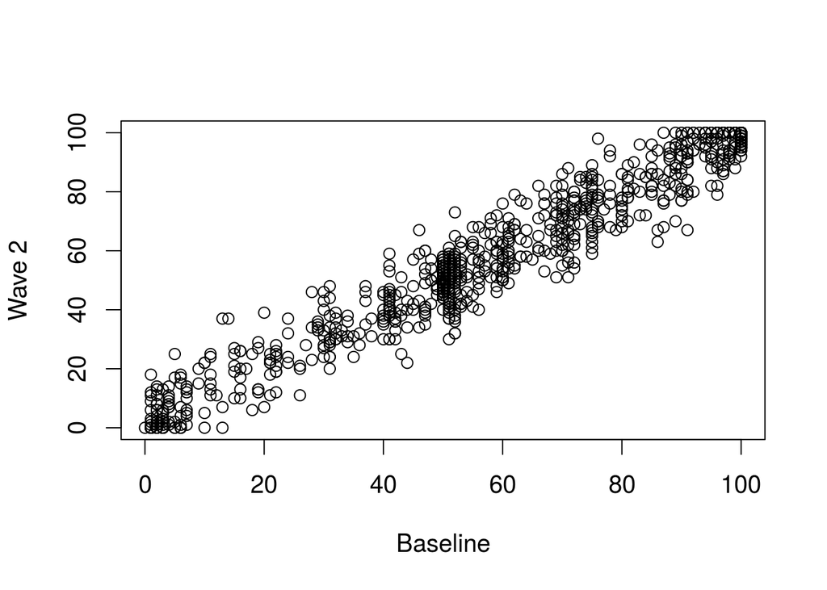

```r
par(cex = 1.25)
plot(gay2.control$therm1, gay2.control$therm2,
     xlab = "Baseline", ylab = "Wave 2")
```

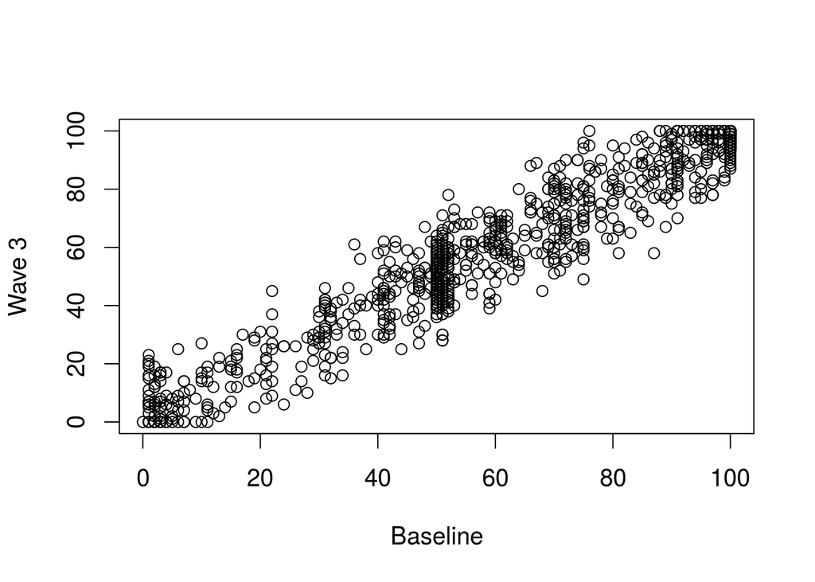

```r
plot(gay2.control$therm1, gay2.control$therm3,
     xlab = "Baseline", ylab = "Wave 3")
```

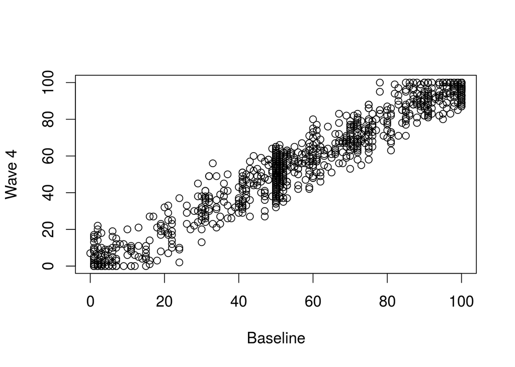

```r
plot(gay2.control$therm1, gay2.control$therm4,
     xlab = "Baseline", ylab = "Wave 4")
```

The figures show no respondents who exhibited changes in their feeling thermometer responses that are out of step with the general pattern of responses in the data. This is highly unusual for data that are alleged to have been drawn from actual survey participants.

## Question 4

The researchers found that the data of the gay marriage study appeared unusually similar to the 2012 CCAP dataset even though they were supposed to be samples of completely different respondents. We use the data contained in `ccap2012.csv` to compare the samples. To get a sense of the distribution of the samples, compute the median and standard deviation for the 2012 CCAP feeling thermometer, the wave 1 feeling thermometer from Study 1, and the wave 1 feeling thermometer from Study 2. Briefly comment on the results.

## Answer 4

```r
## Load CCAP data
ccap <- read.csv("data/ccap2012.csv")
## Compute medians and std. deviations
median(ccap$gaytherm, na.rm = TRUE)
```

```
[1] 54
```

```r
median(gay1$therm1, na.rm = TRUE)
```

```
[1] 52
```

```r
median(gay2$therm1, na.rm = TRUE)
```

```
[1] 52
```

```r
sd(ccap$gaytherm, na.rm = TRUE)
```

```
[1] 29.36892
```

```r
sd(gay1$therm1, na.rm = TRUE)
```

```
[1] 28.50288
```

```r
sd(gay2$therm1, na.rm = TRUE)
```

```
[1] 28.55804
```

The medians and standard deviations of all samples are (or are nearly) the same. This suggests that the distributions of the CCAP as well as gay marriage study, wave 1 data and gay marriage study 1 and study 2, wave 1 data may be quite similar to one another. This is consistent with the claim that the study data were not collected as described, and instead were generated from the 2012 CCAP data.

## Question 5

Create a histogram of the 2012 CCAP feeling thermometer, the wave 1 feeling thermometer from Study 1, and the wave 1 feeling thermometer from Study 2 to help visualize their respective distributions. Note that there are a large number of missing values in the CCAP data. Consider how the missing data might have been recoded in the gay marriage study. To facilitate comparison across histograms, use the `breaks` argument in the `hist` function to keep the bin sizes equal cross histograms. Provide a brief substantive review of the results. **Hint:** The `is.na()` function might prove useful for this question. This function acts like a logical test, returning `TRUE` for all values of its argument that are `NA` and returning `FALSE` for all values of its argument that are not `NA`.

## Answer 5

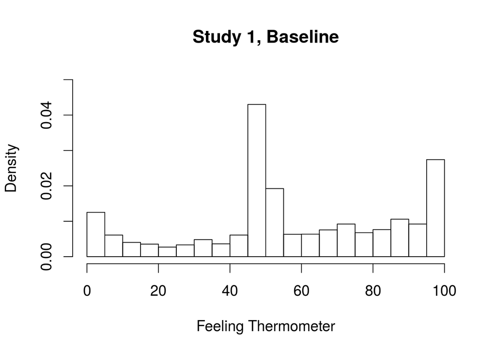

```r
par(cex = 1.25)

## Generate histograms
hist(gay1$therm1, freq = FALSE, breaks = 20, ylim = c(0, 0.05),
     xlab = "Feeling Thermometer", main = "Study 1, Baseline")
```

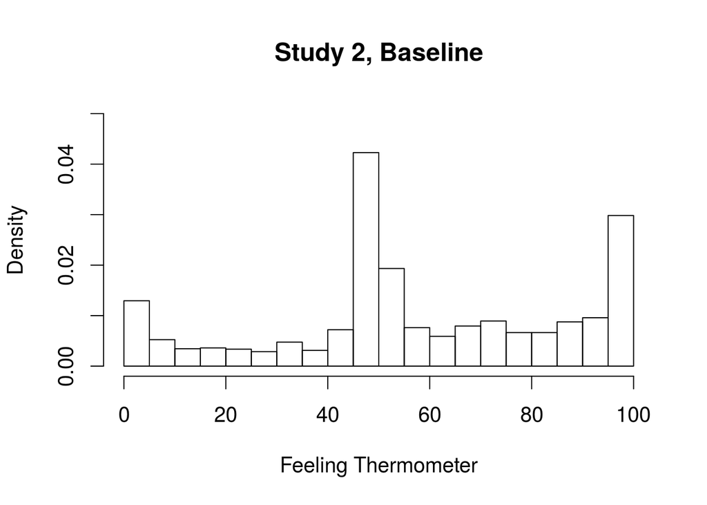

```r
hist(gay2$therm1, freq = FALSE, breaks = 20, ylim = c(0, 0.05),
     xlab = "Feeling Thermometer", main = "Study 2, Baseline")
```

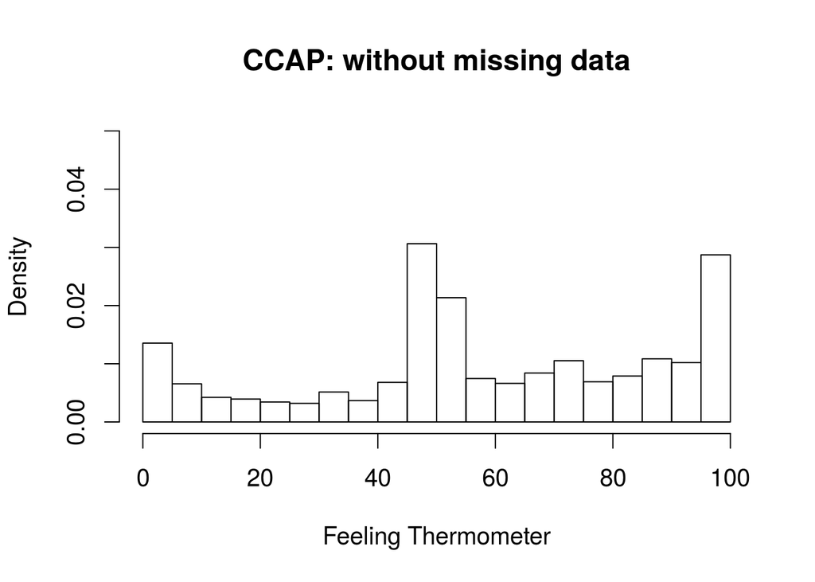

```r
hist(ccap$gaytherm, freq = FALSE, breaks = 20, ylim = c(0, 0.05),
     xlab = "Feeling Thermometer", main = "CCAP: without missing data")
```

```r
## proportion of observations that are equal to 50
mean(gay1$therm1 == 50)
```

```
[1] 0.1931209
```

```r
mean(gay2$therm1 == 50)
```

```
[1] 0.187628
```

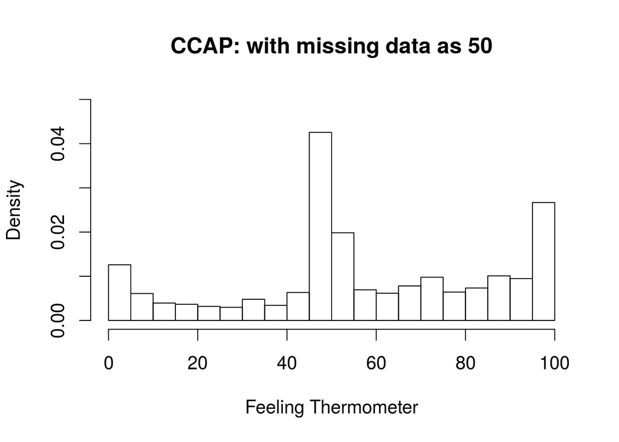

```r
## Replace NAs with 50
ccap$gaytherm[is.na(ccap$gaytherm)] <- 50
hist(ccap$gaytherm, freq = FALSE, breaks = 20, ylim = c(0, 0.05),
     xlab = "Feeling Thermometer",
     main = "CCAP: with missing data as 50")
```